# Simulation study for microdosing study

2024-09-12

# Load libraries

```r
library(glmmTMB)
library(dplyr)
library(MASS)
library(tmvtnorm)
library(truncnorm)
library(lmerTest)
library(lme4)
library(tidyr)
library(reshape2)
library(ggplot2)
library(tibble)
library(purrr)
```

# Data importing and tidying

First, I imported the data from the previous study. I’m only focussing on the count data and the ASC retrospective questionnaire data for now. There was also another questionnaire used (the IEQ).

```r
Count <- read.csv("~/Desktop/Count.csv")
ASC <- read.csv("~/Desktop/ASC.csv")
```

Some tidying

```r
ASC <- ASC%>%
  rename(Participant_Number = Participant.number,
         Simple_Complex = ASC.dimension,
         Average_Score = Average.score) %>%
      mutate(Simple_Complex = case_when(
      Simple_Complex == "Elementary imagery" ~ "Simple",
      Simple_Complex == "Complex imagery" ~ "Complex",
      TRUE ~ Simple_Complex)) %>%
      dplyr::select(Participant_Number, Simple_Complex, Average_Score, Condition)

Count$X <- NULL

Count <- Count %>%
  dplyr::select(-Proportional_count)
```

```r
head(ASC)
```

```
##   Participant_Number Simple_Complex Average_Score Condition
## 1                  8         Simple     87.500000   Flicker
## 2                  8        Complex     23.333333   Flicker
## 3                  8         Simple      0.000000  Ganzfeld
## 4                  8        Complex      0.000000  Ganzfeld
## 5                  9         Simple     40.000000   Flicker
## 6                  9        Complex      8.333333   Flicker
```

```r
head(Count)
```

```
##   Participant_Number Simple_Complex Condition Hallucination_Count
## 1                  8         Simple   Flicker                   4
## 2                  8         Simple  Ganzfeld                   0
## 3                  8        Complex   Flicker                   0
## 4                  8        Complex  Ganzfeld                   0
## 5                  9         Simple   Flicker                  42
## 6                  9         Simple  Ganzfeld                   2
```

# Effect sizes

I used the effect sizes from Cavanna, F., Muller, S., de la Fuente, L.A. et al. Microdosing with psilocybin mushrooms: a double-blind placebo-controlled study. Transl Psychiatry 12, 307 (2022). https://doi.org/10.1038/s41398-022-02039-0, Supplementary Table S1. This was a repeated measures study with 34 participants. Participants were asked on a VAS scale from 0-100 about the self reported intensity on 0.5g of mushrooms compared to placebo. The dosing days were over two days, Wednesday and Friday. I used the effect sizes from the Wednesday. The statistics are reportes as Mean +/- SEM, I have converted the SEM to SD.

```r
#Psilocybin effect sizes
n_study <- 34
mean_psilo <- 67.88
mean_placebo <- 37.29
#convert SEM to SD
sd_psilo <- 6.09*sqrt(34)
sd_placebo <- 2.48*sqrt(34)

# calculate Cohen's d from summary statistics
cohens_d_aggregate <- function(mean_x, mean_y, sd_x, sd_y, n_x, n_y) {
  # Pooled standard deviation
  pooled_sd <- sqrt(((n_x - 1) * sd_x^2 + (n_y - 1) * sd_y^2) / (n_x + n_y - 2))
  # Cohen's d
  d <- (mean_x - mean_y) / pooled_sd

  return(d)
}

cohensd_psilo <- cohens_d_aggregate(mean_psilo, mean_placebo, sd_psilo, sd_placebo, n_study, n_study)

print (paste("The cohens d for the microdosing study is", round(cohensd_psilo, 2)))
```

```
## [1] "The cohens d for the microdosing study is 1.13"
```

I then get the summary statistics from the count and the ASC data

```r
#hallucination count from original study
summary_stats <- Count %>%
  group_by(Simple_Complex, Condition) %>%
  summarise(
    mean_hallucination = mean(Hallucination_Count, na.rm = TRUE),
    sd_hallucination = sd(Hallucination_Count, na.rm = TRUE)
  )
summary_stats
```

```
## # A tibble: 4 × 4
## # Groups:   Simple_Complex [2]
##   Simple_Complex Condition mean_hallucination sd_hallucination
##   <chr>          <chr>                  <dbl>            <dbl>
## 1 Complex        Flicker                 1.4              2.50
## 2 Complex        Ganzfeld                1.4              2.09
## 3 Simple         Flicker                16.2             14.7
## 4 Simple         Ganzfeld                5.53             6.46
```

```r
#ASC from original study
summary_stats_ASC <- ASC %>%
  group_by(Simple_Complex, Condition) %>%
  summarise(
    mean_ASC = mean(Average_Score, na.rm = TRUE),
    sd_ASC = sd(Average_Score, na.rm = TRUE)
  )
summary_stats_ASC
```

```
## # A tibble: 4 × 4
## # Groups:   Simple_Complex [2]
##   Simple_Complex Condition mean_ASC sd_ASC
##   <chr>          <chr>        <dbl>  <dbl>
## 1 Complex        Flicker       24.4   22.2
## 2 Complex        Ganzfeld      15.2   24.6
## 3 Simple         Flicker       66.0   26.6
## 4 Simple         Ganzfeld      40.4   28.8
```

```r
ganzflicker_simple_mu_count <- summary_stats %>%
  filter(Simple_Complex == "Simple" & Condition == "Flicker") %>%
  pull(mean_hallucination)

ganzflicker_simple_mu_ASC<- summary_stats_ASC %>%
  filter(Simple_Complex == "Simple" & Condition == "Flicker") %>%
  pull(mean_ASC)

ganzflicker_simple_sd_count <- summary_stats %>%
  filter(Simple_Complex == "Simple" & Condition == "Flicker") %>%
  pull(sd_hallucination)

ganzflicker_simple_sd_ASC <- summary_stats_ASC %>%
  filter(Simple_Complex == "Simple" & Condition == "Flicker") %>%
  pull(sd_ASC)

ganzflicker_complex_mu_count <- summary_stats %>%
  filter(Simple_Complex == "Complex" & Condition == "Flicker") %>%
  pull(mean_hallucination)

ganzflicker_complex_mu_ASC <- summary_stats_ASC %>%
  filter(Simple_Complex == "Complex" & Condition == "Flicker") %>%
  pull(mean_ASC)

ganzflicker_complex_sd_count <- summary_stats %>%
  filter(Simple_Complex == "Complex" & Condition == "Flicker") %>%
  pull(sd_hallucination)

ganzflicker_complex_sd_ASC <- summary_stats_ASC %>%
  filter(Simple_Complex == "Complex" & Condition == "Flicker") %>%
  pull(sd_ASC)

ganzfeld_simple_mu_count <- summary_stats %>%
  filter(Simple_Complex == "Simple" & Condition == "Ganzfeld") %>%
  pull(mean_hallucination)

ganzfeld_simple_mu_ASC <- summary_stats_ASC %>%
  filter(Simple_Complex == "Simple" & Condition == "Ganzfeld") %>%
  pull(mean_ASC)

ganzfeld_simple_sd_count <- summary_stats %>%
  filter(Simple_Complex == "Simple" & Condition == "Ganzfeld") %>%
  pull(sd_hallucination)

ganzfeld_simple_sd_ASC <- summary_stats_ASC %>%
  filter(Simple_Complex == "Simple" & Condition == "Ganzfeld") %>%
  pull(sd_ASC)

ganzfeld_complex_mu_count <- summary_stats %>%
  filter(Simple_Complex == "Complex" & Condition == "Ganzfeld") %>%
  pull(mean_hallucination)

ganzfeld_complex_mu_ASC <- summary_stats_ASC %>%
  filter(Simple_Complex == "Complex" & Condition == "Ganzfeld") %>%
  pull(mean_ASC)

ganzfeld_complex_sd_count <- summary_stats %>%
  filter(Simple_Complex == "Complex" & Condition == "Ganzfeld") %>%
  pull(sd_hallucination)

ganzfeld_complex_sd_ASC <- summary_stats_ASC %>%
  filter(Simple_Complex == "Complex" & Condition == "Ganzfeld") %>%
  pull(sd_ASC)
```

I then estimate the mean of the psilocybin arm for the ASC questionnaire - I have conservatively assumed a 0.8 effect size

```r
#estimated mean of psilocybin ASC based on cohens d of 0.8 for all combinations of ganzfeld/flicker/simple/complex

n_study <- 30

# Cohen's d (0.8) = (mean_x - mean_y) / pooled_sd
#solve for mean-y
#0.8 * pooled sd + mean_x

#ganzflicker simple
est_mean_psilo_ganzflicker_simple_ASC <- 0.8*ganzflicker_simple_sd_ASC + ganzflicker_simple_mu_ASC
print(paste("Simple ganzflicker psilocybin ASC mean:", est_mean_psilo_ganzflicker_simple_ASC))
```

```
## [1] "Simple ganzflicker psilocybin ASC mean: 87.2719182992205"
```

```r
#ganzflicker complex
est_mean_psilo_ganzflicker_complex_ASC <- 0.8*ganzflicker_complex_sd_ASC + ganzflicker_complex_mu_ASC
print(paste("Complex ganzflicker psilocybin ASC mean:", est_mean_psilo_ganzflicker_complex_ASC))
```

```
## [1] "Complex ganzflicker psilocybin ASC mean: 42.1318752501685"
```

```r
#ganzfeld simple
est_mean_psilo_ganzfeld_simple_ASC <- 0.8*ganzfeld_simple_sd_ASC + ganzfeld_simple_mu_ASC
print(paste("Simple ganzfeld psilocybin ASC mean:", est_mean_psilo_ganzfeld_simple_ASC))
```

```
## [1] "Simple ganzfeld psilocybin ASC mean: 63.3534839939968"
```

```r
#ganzfeld complex
est_mean_psilo_ganzfeld_complex_ASC <- 0.8*ganzfeld_complex_sd_ASC + ganzfeld_complex_mu_ASC
print(paste("Complex ganzfeld psilocybin ASC mean:", est_mean_psilo_ganzfeld_complex_ASC))
```

```
## [1] "Complex ganzfeld psilocybin ASC mean: 34.8841387418313"
```

I do the same for the count data and round to the nearest whole number

```r
#ganzflicker simple
est_mean_psilo_ganzflicker_simple_count <- round(0.8*ganzflicker_simple_sd_count + ganzflicker_simple_mu_count)
print(paste("Simple ganzflicker psilocybin count mean:", est_mean_psilo_ganzflicker_simple_count))
```

```
## [1] "Simple ganzflicker psilocybin count mean: 28"
```

```r
#ganzflicker complex
est_mean_psilo_ganzflicker_complex_count <- round(0.8*ganzflicker_complex_sd_count + ganzflicker_complex_mu_count)
print(paste("Complex ganzflicker psilocybin count mean:", est_mean_psilo_ganzflicker_complex_count))
```

```
## [1] "Complex ganzflicker psilocybin count mean: 3"
```

```r
#ganzfeld simple
est_mean_psilo_ganzfeld_simple_count <- round(0.8*ganzfeld_simple_sd_count + ganzfeld_simple_mu_count)
print(paste("Simple ganzfeld psilocybin count mean:", est_mean_psilo_ganzfeld_simple_count))
```

```
## [1] "Simple ganzfeld psilocybin count mean: 11"
```

```r
#ganzfeld complex
est_mean_psilo_ganzfeld_complex_count <- round(0.8*ganzfeld_complex_sd_count + ganzfeld_complex_mu_count)
print(paste("Complex ganzfeld psilocybin count mean:", est_mean_psilo_ganzfeld_complex_count))
```

```
## [1] "Complex ganzfeld psilocybin count mean: 3"
```

I then estimate the size parameter for the rnbinom function

https://stats.stackexchange.com/questions/225544/simulating-an-overdispersed-negative-binomial-distribution

“An alternative parametrization (often used in ecology) is by the mean ‘mu’ (see above), and ‘size’, the dispersion parameter, where ‘prob’ = size/(size+mu)’. The variance is ‘mu + mu^2/size’ in this parametrization”

“Solve for size by mean^2/(variance-mean)”

```r
# Calculate size for each condition
calculate_size <- function(mu, sd) {
  return((mu^2) / (sd^2 - mu))
}

# Ganzflicker Simple
ganzflicker_simple_size <- calculate_size(ganzflicker_simple_mu_count, ganzflicker_simple_sd_count)

# Ganzflicker Complex
ganzflicker_complex_size <- calculate_size(ganzflicker_complex_mu_count, ganzflicker_complex_sd_count)

# Ganzfeld Simple
ganzfeld_simple_size <- calculate_size(ganzfeld_simple_mu_count, ganzfeld_simple_sd_count)

# Ganzfeld Complex
ganzfeld_complex_size <- calculate_size(ganzfeld_complex_mu_count, ganzfeld_complex_sd_count)
```

This is where I left off for the count data as I’m not sure how to simulate correlated/non-independent binomial data.

# Simulating the data

I then begin simulating the ASC data

```r
#simulate one data set for 30 participants
set.seed(123)
n <- 30  # number of participants
```

I am assuming the placebo arm is the same as no treatment.

However, I want the psilocybin arm and the placebo arm to be highly correlated with each other for both the ASC and the count arms. I am not sure how correlated the placebo/psilocybin arms would be with each other and I can’t find much in the literature? I would estimate quite highly but this is just a complete guess. I’ve put in a placeholder of 0.9. I did this by adding some jitter to the placebo variables and assigning it as psilocybin variables as a placeholder to calculate but not sure if this is the right thing to do as in the correlation matrix it still equals 1.00 correlation.

```r
# wide data and add placebo arm
wide_data <- ASC %>%
  pivot_wider(names_from = c(Simple_Complex, Condition),
              values_from = Average_Score,
              values_fill = list(Average_Score = 0)) %>%
  rename(
    Simple_Flicker_Placebo = Simple_Flicker,
    Complex_Flicker_Placebo = Complex_Flicker,
    Simple_Ganzfeld_Placebo = Simple_Ganzfeld,
    Complex_Ganzfeld_Placebo = Complex_Ganzfeld
  ) %>%
  # create new columns for psilcoybin, copying the values from the corresponding _Placebo columns and adding 10% jitter
  mutate(
Simple_Flicker_Psilocybin = Simple_Flicker_Placebo * (1 + runif(length(Simple_Flicker_Placebo), -0.10, 0.10)),
Complex_Flicker_Psilocybin = Complex_Flicker_Placebo * (1 + runif(length(Complex_Flicker_Placebo), -0.10, 0.10)),
Simple_Ganzfeld_Psilocybin = Simple_Ganzfeld_Placebo * (1 + runif(length(Simple_Ganzfeld_Placebo), -0.10, 0.10)),
Complex_Ganzfeld_Psilocybin = Complex_Ganzfeld_Placebo * (1 + runif(length(Complex_Ganzfeld_Placebo), -0.10, 0.10))
  )
```

I then work out the correlations between all of the different variables

```r
# Calculate pairwise correlations between all combinations of Simple/Complex and Flicker/Ganzfeld
cor_matrix <- cor(wide_data %>%
                    dplyr::select(
                      Simple_Flicker_Placebo, Simple_Ganzfeld_Placebo, Complex_Flicker_Placebo, Complex_Ganzfeld_Placebo,
                      Simple_Flicker_Psilocybin, Simple_Ganzfeld_Psilocybin, Complex_Flicker_Psilocybin, Complex_Ganzfeld_Psilocybin))
```

Then I use rmultinorm to simulate the data so it isn’t independent from each other, using the correlation matrix previously calculated

```r
library(faux)
#first define means and SDs
means <- c(ganzflicker_simple_mu_ASC,
           ganzfeld_simple_mu_ASC,
           ganzflicker_complex_mu_ASC,
           ganzfeld_complex_mu_ASC,
           est_mean_psilo_ganzflicker_simple_ASC,
          est_mean_psilo_ganzflicker_complex_ASC,
           est_mean_psilo_ganzfeld_simple_ASC,
           est_mean_psilo_ganzfeld_complex_ASC
              )

#i assume the SDs are the same as the placebo SDs
sds <- c( ganzflicker_simple_sd_ASC,
          ganzfeld_simple_sd_ASC,
          ganzflicker_complex_sd_ASC,
          ganzfeld_complex_sd_ASC,
          ganzflicker_simple_sd_ASC,
          ganzfeld_simple_sd_ASC,
          ganzflicker_complex_sd_ASC,
          ganzfeld_complex_sd_ASC)

simulated_data_ASC <- rnorm_multi(n=30,
              mu = means,
              sd = sds,
              r = cor_matrix,
              varnames = colnames(cor_matrix))
```

This creates simulated_data_ASC, however this needs to be truncated as it isn’t capped at 100 and dips below 0 - chat GPT suggests re-simulating with truncnorm?

```r
library(truncnorm)

# Function to simulate data from a truncated normal distribution
simulate_truncated_normal <- function(n, mu, sd, lower, upper) {
  rtruncnorm(n, a = lower, b = upper, mean = mu, sd = sd)
}

# Simulate data for each variable separately, maintaining the correlation structure
simulated_data_list <- lapply(1:ncol(cor_matrix), function(i) {
  simulate_truncated_normal(n = 30, mu = means[i], sd = sds[i], lower = 0, upper = 100)
})

# Combine into a matrix
simulated_data_truncated <- do.call(cbind, simulated_data_list)

# Ensure the column names match the original variable names
colnames(simulated_data_truncated) <- colnames(cor_matrix)
```

Checking for the differences between the truncated and non truncated data set

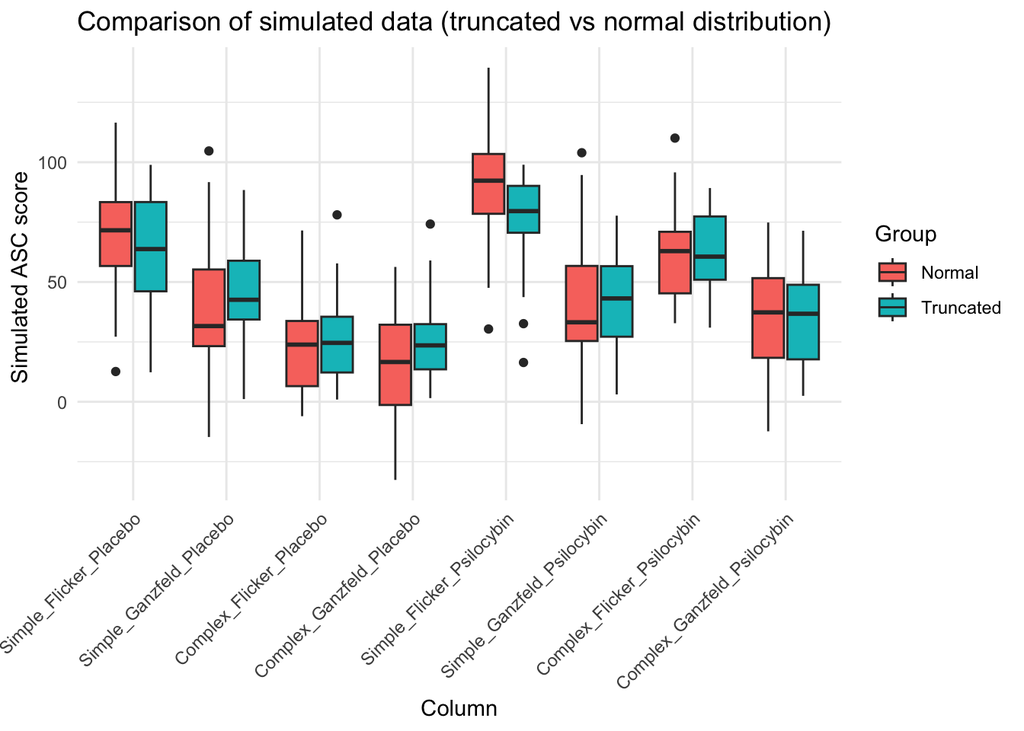

```r
df_truncated <- as.data.frame(simulated_data_truncated)
df_ASC <- as.data.frame(simulated_data_ASC)

df_truncated$Group <- 'Truncated'
df_ASC$Group <- 'Normal'

# combine & reshape
combined_data <- rbind(df_truncated, df_ASC)
combined_long <- melt(combined_data, id.vars = 'Group', variable.name = 'Variable', value.name = 'Value')

# boxplot
ggplot(combined_long, aes(x = Variable, y = Value, fill = Group)) +
  geom_boxplot() +
  labs(title = "Comparison of simulated data (truncated vs normal distribution)",
       x = "Column",
       y = "Simulated ASC score ") +
  theme_minimal() +
  theme(axis.text.x = element_text(angle = 45, hjust = 1))  # Angle the x-axis labels
```

```r
# T-tests between corresponding columns
t_test_results <- data.frame(Variable = colnames(simulated_data_truncated), t_value = NA, p_value = NA)

for (i in 1:ncol(simulated_data_truncated)) {
  t_test <- t.test(simulated_data_truncated[, i], simulated_data_ASC[, i])
  t_test_results$t_value[i] <- t_test$statistic
  t_test_results$p_value[i] <- t_test$p.value
}

print(t_test_results)
```

```
##                      Variable     t_value     p_value
## 1      Simple_Flicker_Placebo -1.30403729 0.197372722
## 2     Simple_Ganzfeld_Placebo  0.99498123 0.324385472
## 3     Complex_Flicker_Placebo  0.70018953 0.486648367
## 4    Complex_Ganzfeld_Placebo  1.78307598 0.080061833
## 5   Simple_Flicker_Psilocybin -2.66812022 0.009992638
## 6  Simple_Ganzfeld_Psilocybin  0.54833233 0.585831907
## 7  Complex_Flicker_Psilocybin -0.05321784 0.957746684
## 8 Complex_Ganzfeld_Psilocybin -0.37021496 0.712596932
```

I then add a column for participant number

```r
simulated_data_ASC_perp <- data.frame(
  Participant = 1:n,
  simulated_data_truncated)
```

And convert the data to being long again

```r
simulated_data_ASC_long <- simulated_data_ASC_perp %>%
  pivot_longer(cols = -Participant,
               names_to = c("Complexity", "Condition", "Drug"),
               names_sep = "_",
               values_to = "ASC_Score")
```

I then run the model for one set of data

```r
model_ASC <- lmer(ASC_Score ~ Condition + Complexity*Drug + (1 | Participant), data = simulated_data_ASC_long)
```

```
## boundary (singular) fit: see help('isSingular')
```

```r
summary(model_ASC)
```

```
## Linear mixed model fit by REML. t-tests use Satterthwaite's method [
## lmerModLmerTest]
## Formula: ASC_Score ~ Condition + Complexity * Drug + (1 | Participant)
##    Data: simulated_data_ASC_long
##
## REML criterion at convergence: 2102.2
##
## Scaled residuals:
##      Min       1Q   Median       3Q      Max
## -2.60003 -0.61431  0.02205  0.70882  2.84479
##
## Random effects:
##  Groups      Name        Variance Std.Dev.
##  Participant (Intercept)   0.0     0.00
##  Residual                411.8    20.29
## Number of obs: 240, groups:  Participant, 30
##
## Fixed effects:
##                                 Estimate Std. Error      df t value Pr(>|t|)
## (Intercept)                       36.143      2.929 235.000  12.339  < 2e-16
## ConditionGanzfeld                -19.685      2.620 235.000  -7.514 1.20e-12
## ComplexitySimple                  26.421      3.705 235.000   7.131 1.22e-11
## DrugPsilocybin                    22.152      3.705 235.000   5.979 8.30e-09
## ComplexitySimple:DrugPsilocybin  -15.544      5.240 235.000  -2.966  0.00332
##
## (Intercept)                     ***
## ConditionGanzfeld               ***
## ComplexitySimple                ***
## DrugPsilocybin                  ***
## ComplexitySimple:DrugPsilocybin **
## ---
## Signif. codes:  0 '***' 0.001 '**' 0.01 '*' 0.05 '.' 0.1 ' ' 1
##
## Correlation of Fixed Effects:
##             (Intr) CndtnG CmplxS DrgPsl
## CndtnGnzfld -0.447
## CmplxtySmpl -0.632  0.000
## DrugPslcybn -0.632  0.000  0.500
## CmplxtyS:DP  0.447  0.000 -0.707 -0.707
## optimizer (nloptwrap) convergence code: 0 (OK)
## boundary (singular) fit: see help('isSingular')
```

# Power analysis

I then put it all in a function to calculate power

```r
analyse_simulation <- function() {
  # Set random seed and number of participants
  set.seed(123)
  n <- 30  # number of participants

  # Simulate wide data (placebo arm)
  wide_data <- ASC %>%
    pivot_wider(names_from = c(Simple_Complex, Condition),
                values_from = Average_Score,
                values_fill = list(Average_Score = 0)) %>%
    rename(
      Simple_Flicker_Placebo = Simple_Flicker,
      Complex_Flicker_Placebo = Complex_Flicker,
      Simple_Ganzfeld_Placebo = Simple_Ganzfeld,
      Complex_Ganzfeld_Placebo = Complex_Ganzfeld
    ) %>%
    # Add jitter for psilocybin arm
    mutate(
      Simple_Flicker_Psilocybin = Simple_Flicker_Placebo * (1 + runif(length(Simple_Flicker_Placebo), -0.10, 0.10)),
      Complex_Flicker_Psilocybin = Complex_Flicker_Placebo * (1 + runif(length(Complex_Flicker_Placebo), -0.10, 0.10)),
      Simple_Ganzfeld_Psilocybin = Simple_Ganzfeld_Placebo * (1 + runif(length(Simple_Ganzfeld_Placebo), -0.10, 0.10)),
      Complex_Ganzfeld_Psilocybin = Complex_Ganzfeld_Placebo * (1 + runif(length(Complex_Ganzfeld_Placebo), -0.10, 0.10))
    )

  # Calculate correlation matrix
  cor_matrix <- cor(wide_data %>%
                      dplyr::select(
                        Simple_Flicker_Placebo, Simple_Ganzfeld_Placebo, Complex_Flicker_Placebo, Complex_Ganzfeld_Placebo,
                        Simple_Flicker_Psilocybin, Simple_Ganzfeld_Psilocybin, Complex_Flicker_Psilocybin, Complex_Ganzfeld_Psilocybin))

  # Define means and standard deviations (using placeholder values)
  means <- c(ganzflicker_simple_mu_ASC, ganzfeld_simple_mu_ASC, ganzflicker_complex_mu_ASC, ganzfeld_complex_mu_ASC,
             est_mean_psilo_ganzflicker_simple_ASC, est_mean_psilo_ganzflicker_complex_ASC, est_mean_psilo_ganzfeld_simple_ASC, est_mean_psilo_ganzfeld_complex_ASC)

  sds <- c(ganzflicker_simple_sd_ASC, ganzfeld_simple_sd_ASC, ganzflicker_complex_sd_ASC, ganzfeld_complex_sd_ASC,
           ganzflicker_simple_sd_ASC, ganzfeld_simple_sd_ASC, ganzflicker_complex_sd_ASC, ganzfeld_complex_sd_ASC)

  # Simulate data (truncated)
  simulated_data_list <- lapply(1:ncol(cor_matrix), function(i) {
    rtruncnorm(n = n, a = 0, b = 100, mean = means[i], sd = sds[i])
  })
  simulated_data_truncated <- do.call(cbind, simulated_data_list)
  colnames(simulated_data_truncated) <- colnames(cor_matrix)

  # Add participant numbers and convert to long format
  simulated_data_ASC_perp <- data.frame(Participant = 1:n, simulated_data_truncated)
  simulated_data_ASC_long <- simulated_data_ASC_perp %>%
    pivot_longer(cols = -Participant,
                 names_to = c("Complexity", "Condition", "Drug"),
                 names_sep = "_",
                 values_to = "ASC_Score")

  # Fit a linear mixed-effects model
  model_ASC <- lmer(ASC_Score ~ Condition + Complexity * Drug + (1 | Participant), data = simulated_data_ASC_long)
  model_summary <- summary(model_ASC)

  # Extract and return model coefficients as a tidy data frame
  tidy_summary <- as.data.frame(model_summary$coefficients) %>%
    rownames_to_column(var = "Term") %>%
    dplyr::select(Term, Estimate, `Std. Error`, `Pr(>|t|)`)

  return(tidy_summary)
}
```

I then run once to check if it worked

```r
analyse_simulation()
```

```
## boundary (singular) fit: see help('isSingular')
```

```
##                              Term  Estimate Std. Error     Pr(>|t|)
## 1                     (Intercept)  39.21397   3.034816 3.258091e-29
## 2               ConditionGanzfeld -21.37295   2.714422 1.263186e-13
## 3                ComplexitySimple  22.43199   3.838773 1.695049e-08
## 4                  DrugPsilocybin  25.14364   3.838773 3.592891e-10
## 5 ComplexitySimple:DrugPsilocybin -15.61747   5.428845 4.387342e-03
```

I then run 1000 simulations to check power& then calculagte power (note i have hidden warning as I get) the following error: boundary (singular) fit: see help(‘isSingular’)

```r
simulation_table <- map_df(1:1000, ~analyse_simulation()) %>%
  mutate(sim=rep(1:1000, each=5))
```

```r
power <- simulation_table %>% filter(Term=='ComplexitySimple:DrugPsilocybin') %>%
  mutate(sig=(`Pr(>|t|)` < .05))

power %>% pull(sig) %>% sum()/1000
```

```
## [1] 1
```